# Prior draws for multi-resolution trees

2025-06-09

## Setup

Whereas a standard, parametric multilevel model might assume exchangeability of classroom within schools and exchangeability of schools within districts, we will consider alternative specifications induced by tree-based recursive partitions. The key idea is that the prior correlation between random effects corresponding to a pair of classroom is proportional to the prior probability that the two classrooms are assigned to the same leaf of a tree. So in subsequent sections, we will use the function `flexBART::rflexBART` to simulate many tree draws and approximate this probability. We will focus, in particular, on how different priors for selecting the splitting probability induce different correlation structures. Because we only care about the co-clustering based on the partitioning of the categorical variables, we will create one student per classroom.

We first generate a dataset with the desired nested structure.

```r
nested <- data.frame(Classroom = 0:119)
nested$School <- floor(nested$Classroom/5)
nested$District <- floor(nested$School/6)

nested$Classroom <- factor(nested$Classroom, levels = 0:119)
nested$School <- factor(nested$School, levels = 0:23)
nested$District <- factor(nested$District, levels = 0:3)
```

We also write a helper function to visualize the pairwise co-clustering probabilities.

```r
plot_kernel <- function(kernel){

  col_list <- colorBlindness::Blue2DarkRed18Steps
  n <- nrow(kernel)

  legend_seq <- seq(floor(n/10), floor(9*n/10), length = 500)
  par(mar = c(1,1,5,1), mgp = c(1.8, 0.5, 0))
  plot(1, type = "n", xlim = c(0.5,n+0.5), ylim = c(0.5,n+0.5),
       xaxt = "n", yaxt = "n", xlab = "", ylab = "")
  rect(floor(n/10), par("usr")[4]+0.5,
       floor(9*n/10), par("usr")[4] + 4.5,
       xpd = TRUE)
  for(leg_ix in 1:499){
    rect(legend_seq[leg_ix], par("usr")[4]+0.5,
         legend_seq[leg_ix+1], par("usr")[4]+4.5,
         border = NA,
         col = rgb(colorRamp(col_list, bias = 1)((leg_ix-1)/500)/255),
         xpd = TRUE)
  }
  text(x = seq(floor(n/10), floor(9*n/10), length = 5),
       y = par("usr")[4]+7.5,
       labels = seq(0,1,length = 5), xpd = TRUE)
  for(i in 1:(n-1)){
    for(j in (i+1):n){
      rect(i-0.5,j-0.5,i+0.5, j+0.5,
           border = NA, col = rgb(colorRamp(col_list, bias = 1)(kernel[i,j])/255))
      rect(j-0.5,i-0.5,j+0.5, i+0.5,
           border = NA, col = rgb(colorRamp(col_list, bias = 1)(kernel[i,j])/255))
    }
    rect(i-0.5,i-0.5,i+0.5, i+0.5,
         border = NA, col = rgb(colorRamp(col_list, bias = 1)(kernel[i,i])/255))
  }
  rect(n-0.5,n-0.5,n+0.5, n+0.5,
       border = NA, col = rgb(colorRamp(col_list, bias = 1)(kernel[i,i])/255))
  abline(h = 1:(n+1) - 0.5, col = 'lightgray')
  abline(v = 1:(n+1) - 0.5, col = 'lightgray')

}
```

## How **flexBART** represents and leverages nesting structure

The functions `flexBART::flexBART`, `flexBART::probit_flexBART`, and `flexBART::rflexBART` automatically check for nesting structure among the categorical predictors provided in the training and optional testing data. Internally, these functions create a directed graph $\mathcal{G}$ whose vertices corresponding to categorical variables and whose edges encode nesting relationship so that if variable $X_{j}$ is nested within $X_{k}$ an edge is drawn from $j$’s vertex in the graph to $k$’s vertex in the graph. They then compute the connected components of $\mathcal{G},$ which we will denote as $C_{1}, \ldots, C_{K}.$

In this running example with classrooms nested within school nested within districts, suppose we decide to split on Classroom after after having already split on School. Since `Classroom` is nested within `School`, the initial split implicitly partitions `Classrooms`, which restricts the set of available values.

In **flexBART**, we can either ignore this restriction (`nest_c = FALSE`) or account for it (`nest_c = TRUE`). If we ignore this restriction, it can be the case that the tree assigns levels which can never reach a node to the left or right child. Since the choice of splitting variable is decoupled from the number of available values of each variable, toggling this argument is unlikely to affect the predictive performance.

More substantively, when `nest_v = FALSE`, the prior selects a splitting variable according to a vector $\theta^{\top} = (\theta_{1}, \ldots, \theta_{p}).$ Depending on the argument `sparse`, the vector of splitting probabilities is fixed with $\theta_{j} = 1/p$ for all j (`sparse=FALSE`) or are learned adaptively using the approach of [Linero (2018)](https://doi.org/10.1111/rssb.12293), which specifies a sparsity-inducing Dirichlet prior for $\theta.$

When `nest_v = TRUE`, **flexBART** functions support four different options for selecting the splitting variable, which are encoded with the `nest_v_option`, which is expected to take values 0, 1, 2, or 3. At a given node , we initialize a vector of un-normalized splitting probabilities $\tilde{\theta}^{\top} = (\tilde{\theta}_{1}, \ldots, \tilde{\theta}_{p})$ by setting $\tilde{\theta}_{j} = 1$ for all continuous $X_{j}$’s and setting $\tilde{\theta}_{j} = 0$ for all categorical $X_{j}$’s. We then loop over the connected components to see if any variable from $C_{k}$ was used at one of ’s ancestors. If so, we identify a representative $v_{k}^{\text{rep}},$ which is the most recently used variable used from the cluster. If not, we say that $C_{k}$ has no valid representative at . We describe how we then set some of the categorial $\tilde{\theta}_{j}$’s to 1 by considering two cases for each cluster $C_{k}.$

**Case 1**: If $C_{k}$ has a valid representative, then we set $\tilde{\theta}_{v^{\text{rep}}_{k}} = 1.$ We set additional $\tilde{\theta}_{j}$’s to 1 based on `nest_v_option`: * If `nest_v_option = 0`, we set $\tilde{\theta}_{j} = 0$ for all $j \in C_{k}$ s.t. $j \neq v^{\text{rep}}_{k}.$ This way, the tree is only allowed to split on a previously selected variable from the cluster $C_{k}.$ * If `nest_v_option = 1`, we identify all $j \in C_{k}$ such that $(j,v^{\text{rep}}_{k})$ is an edge in $\mathcal{G}[C_{k}]$ and set the corresponding $\tilde{\theta}_{j}$’s to 1. This way, the tree can split on $v^{\text{rep}}_{k}$ or any higher-resolution variable that is nested within $v^{\text{rep}}_{k}.$ * If `nest_v_option = 2`, we identify all $j \in C_{k}$ such that $(v^{\text{rep}}_{k},j)$ is an edge in $\mathcal{G}[C_{k}]$ and set the corresponding $\tilde{\theta}_{j}$’s to 1. This way, the tree can split on $v^{\text{rep}}_{k}$ or on any lower-resolution variable that nests $v^{\text{rep}}_{k}.$ * If `nest_v_option = 3`, we identify all $j \in C_{k}$ such that $(j,v^{\text{rep}}_{k})$ or $(v^{\text{rep}}_{k},j)$ is an edge in $\mathcal{G}[C_{k}].$ This way, the tree can split on $v^{\text{rep}}_{k},$ on any higher-resolution variable that is nested within the representative, or on any lower-resolution variable that nests the representative.

**Case 2**: If $C_{k}$ does not have a valid representative, then we set the corresponding $\tilde{\theta}_{j}$’s to 1 based on `nest_v_option`: * If `nest_v_option = 0` we set $\tilde{\theta}_{j} = 1$ for all $j \in C_{k}.$ This allows the tree to split on any variable from the component. * If `nest_v_option = 1` we identify those vertices in $\mathcal{G}[C_{k}]$ that only have incoming edges but no outgoing edges. That is, we identify the **lowest** resolution variables in $C_{k}$ and set the corresponding $\tilde{\theta}_{j}$’s to 1. * If `nest_v_option = 2`, we identify those vertices in $\mathcal{G}[C_{k}]$ that only have out-going edges but no in-coming edges. That is, we identify the **highest** resolution variables in $C_{k}$ and set the corresponding $\tilde{\theta}_{j}$’s to 1. * If `nest_v_option = 3,` we identify those vertices in $\mathcal{G}[C_{k}]$ that have both incoming and out-going edges. That is, we identify variables that are not the highest nor the lowest resolution variables in $C_{k}$ and set the corresponding $\tilde{\theat}_{j}$’s to 1.

Generally speaking, `nest_v_option = 0` forces the tree to use a single resolution level, `nest_v_option = 1` encourages trees to split on higher resolutions, `nest_v_option` encourages trees to split on lower resolutions, and `nest_v_option = 3` encourages trees to split on mid-resolution (i.e., not the most extreme).

## Illustration

We simulate 10,000 draws from the tree prior and plot the (estimated) co-clustering probabilities. The smalleste square in the plot represents an individual observation, which in this case is a classroom. We also overlay squares corresponding to the schools and districts.

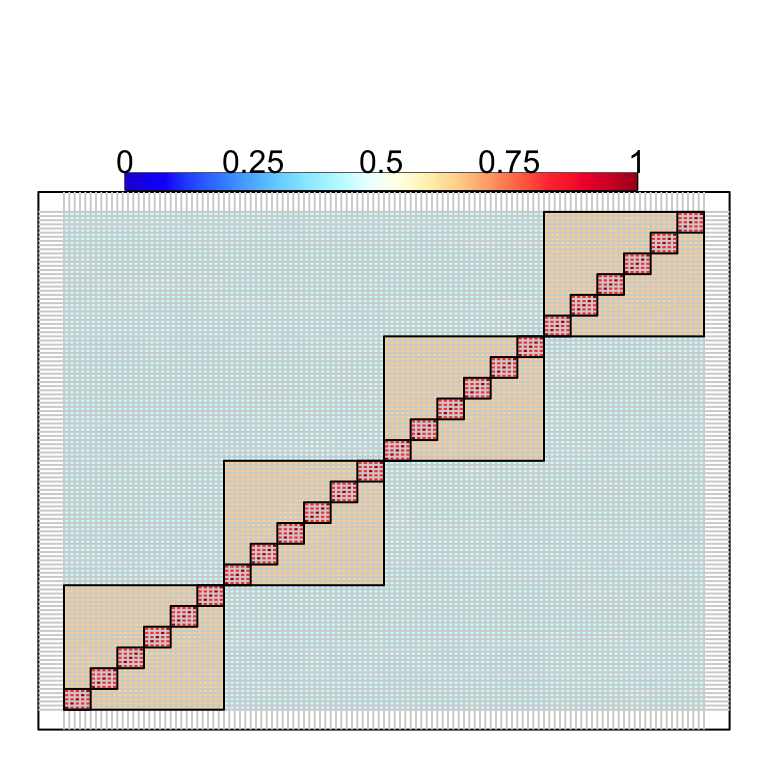

```r
set.seed(609)
partition0 <-
  flexBART::rflexBART(train_data = nested,
                      nd = 1e4,
                      nest_v = TRUE,
                      nest_v_option = 0,
                      nest_c = TRUE,
                      verbose = FALSE)
plot_kernel(partition0$kernel)
for(k in c(0, 30, 60, 90)) rect(k+0.5, k+0.5, k+30.5, k+30.5)
for(k in seq(0, 115, by = 5)) rect(k+0.5, k+0.5, k+5.5, k+5.5)
```

Recall that with `nest_v_option = 0`, the splitting variable is selected uniformly at a random at the root and then fixed for all subsequent nodes. We can verify that this is the case by looking at the matrix of variable counts returned by `flexBART::rflexBART`. Each row of this matrix corresponds to a prior draw and the columns correspond to the variable. We also look at the number of leafs in each sampled tree As expected, there is exactly one non-zero entry in each row corresponding to a non-root tree.

```r
table(partition0$num_leafs)
```

```
##
##    1    2    3    4    5    6    7    8
##  491 5461 2854  866  259   53   15    1
```

```r
table(rowSums(partition0$varcounts != 0))
```

```
##
##    0    1
##  491 9509
```

In some sense, setting `nest_v_option = 0` ignores the nesting structure. Nevertheless, we see that the co-clustering probabilities clearly follow the hierarchical relationship between the variable.

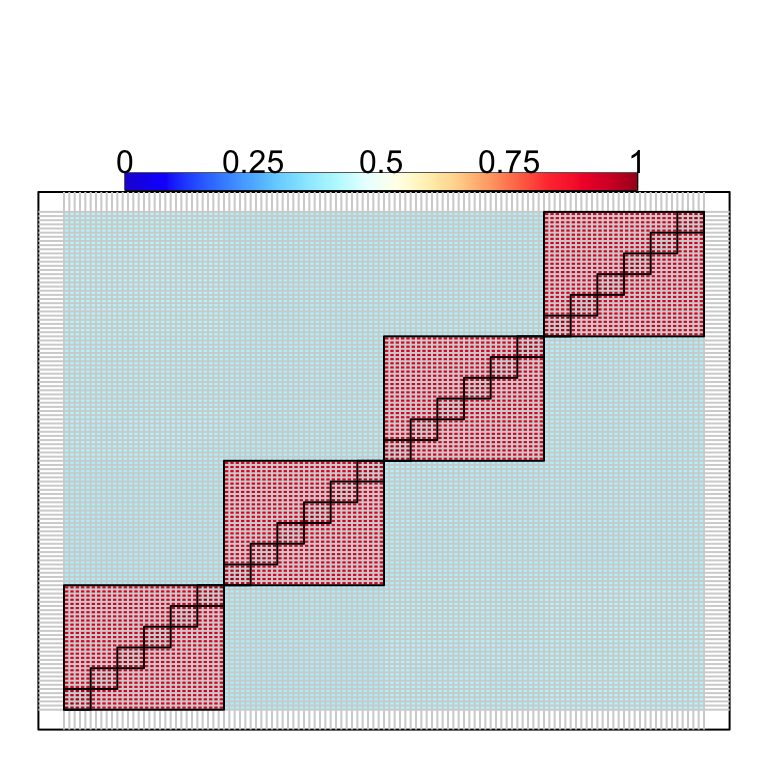

```r
set.seed(609)
partition1 <-
  flexBART::rflexBART(train_data = nested,
                      nd = 1e4,
                      nest_v = TRUE,
                      nest_v_option = 1,
                      nest_c = TRUE,
                      verbose = FALSE)
plot_kernel(partition1$kernel)
for(k in c(0, 30, 60, 90)) rect(k+0.5, k+0.5, k+30.5, k+30.5)
for(k in seq(0, 115, by = 5)) rect(k+0.5, k+0.5, k+5.5, k+5.5)
```

Similarly for `nest_v_option = 2`, the initial splitting variable is always `Classroom.` Subsequently, the tree can split on any of the other variables as `Classroom` is nested within both `School` and `District.`

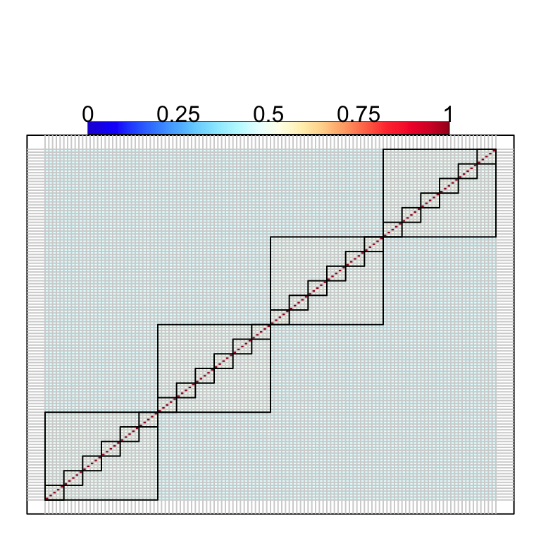

```r
set.seed(609)
partition2 <-
  flexBART::rflexBART(train_data = nested,
                      nd = 1e4,
                      nest_v = TRUE,
                      nest_v_option = 2,
                      nest_c = TRUE,
                      verbose = FALSE)
plot_kernel(partition2$kernel)
for(k in c(0, 30, 60, 90)) rect(k+0.5, k+0.5, k+30.5, k+30.5)
for(k in seq(0, 115, by = 5)) rect(k+0.5, k+0.5, k+5.5, k+5.5)
```

Finally, with `nest_v_option = 3`, the initial splitting variable is always `School`, which is why we see observations from the same school co-clustered very often.

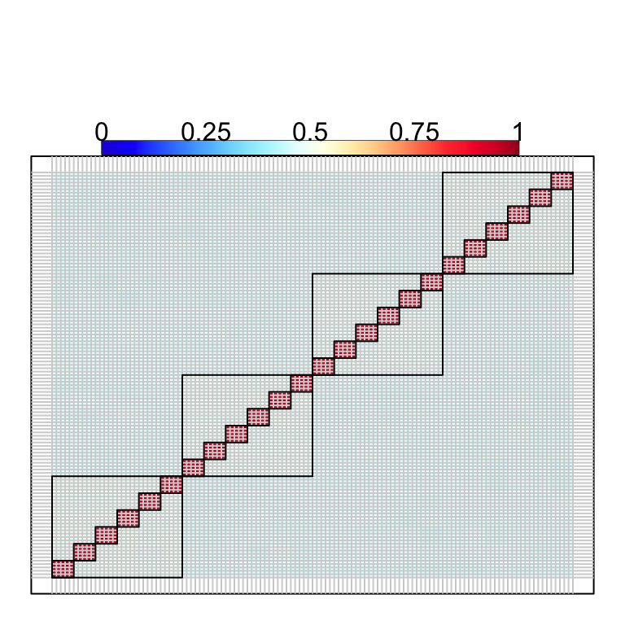

```r
set.seed(609)
partition3 <-
  flexBART::rflexBART(train_data = nested,
                      nd = 1e4,
                      nest_v = TRUE,
                      nest_v_option = 3,
                      nest_c = TRUE,
                      verbose = FALSE)
plot_kernel(partition3$kernel)
for(k in c(0, 30, 60, 90)) rect(k+0.5, k+0.5, k+30.5, k+30.5)
for(k in seq(0, 115, by = 5)) rect(k+0.5, k+0.5, k+5.5, k+5.5)
```